# Risk Factor Analysis

## Outcome Variable

**Outcome Variable:** pers_wast

## Predictor Variables

**Intervention Variable:** earlybf

**Adjustment Set:**

- arm
- sex
- W_mage
- meducyrs
- feducyrs
- hhwealth_quart
- hfoodsec
- W_mhtcm
- vagbrth
- W_birthwt
- W_birthlen
- W_nrooms
- brthmon
- W_parity
- impfloor
- impsan
- safeh20
- delta_W_mage
- delta_meducyrs
- delta_feducyrs
- delta_hhwealth_quart
- delta_hfoodsec
- delta_W_mhtcm
- delta_vagbrth
- delta_W_birthwt
- delta_W_birthlen
- delta_W_nrooms
- delta_brthmon
- delta_W_parity
- delta_impfloor
- delta_impsan
- delta_safeh20

## Stratifying Variables

The analysis was stratified on these variable(s):

- agecat
- studyid
- country

## Data Summary

| agecat | studyid | country | earlybf | pers_wast | n_cell | n |
| --- | --- | --- | --- | --- | --- | --- |
| 0-24 months | ki0047075b-MAL-ED | BANGLADESH | 0 | 0 | 90 | 247 |
| 0-24 months | ki0047075b-MAL-ED | BANGLADESH | 0 | 1 | 5 | 247 |
| 0-24 months | ki0047075b-MAL-ED | BANGLADESH | 1 | 0 | 144 | 247 |
| 0-24 months | ki0047075b-MAL-ED | BANGLADESH | 1 | 1 | 8 | 247 |
| 0-24 months | ki0047075b-MAL-ED | BRAZIL | 0 | 0 | 117 | 217 |
| 0-24 months | ki0047075b-MAL-ED | BRAZIL | 0 | 1 | 1 | 217 |
| 0-24 months | ki0047075b-MAL-ED | BRAZIL | 1 | 0 | 98 | 217 |
| 0-24 months | ki0047075b-MAL-ED | BRAZIL | 1 | 1 | 1 | 217 |
| 0-24 months | ki0047075b-MAL-ED | INDIA | 0 | 0 | 93 | 241 |
| 0-24 months | ki0047075b-MAL-ED | INDIA | 0 | 1 | 5 | 241 |
| 0-24 months | ki0047075b-MAL-ED | INDIA | 1 | 0 | 127 | 241 |
| 0-24 months | ki0047075b-MAL-ED | INDIA | 1 | 1 | 16 | 241 |
| 0-24 months | ki0047075b-MAL-ED | NEPAL | 0 | 0 | 140 | 238 |
| 0-24 months | ki0047075b-MAL-ED | NEPAL | 0 | 1 | 1 | 238 |
| 0-24 months | ki0047075b-MAL-ED | NEPAL | 1 | 0 | 94 | 238 |
| 0-24 months | ki0047075b-MAL-ED | NEPAL | 1 | 1 | 3 | 238 |
| 0-24 months | ki0047075b-MAL-ED | PERU | 0 | 0 | 72 | 284 |
| 0-24 months | ki0047075b-MAL-ED | PERU | 0 | 1 | 0 | 284 |
| 0-24 months | ki0047075b-MAL-ED | PERU | 1 | 0 | 211 | 284 |
| 0-24 months | ki0047075b-MAL-ED | PERU | 1 | 1 | 1 | 284 |
| 0-24 months | ki0047075b-MAL-ED | SOUTH AFRICA | 0 | 0 | 100 | 268 |
| 0-24 months | ki0047075b-MAL-ED | SOUTH AFRICA | 0 | 1 | 1 | 268 |
| 0-24 months | ki0047075b-MAL-ED | SOUTH AFRICA | 1 | 0 | 166 | 268 |
| 0-24 months | ki0047075b-MAL-ED | SOUTH AFRICA | 1 | 1 | 1 | 268 |
| 0-24 months | ki0047075b-MAL-ED | TANZANIA, UNITED REPUBLIC OF | 0 | 0 | 43 | 253 |
| 0-24 months | ki0047075b-MAL-ED | TANZANIA, UNITED REPUBLIC OF | 0 | 1 | 0 | 253 |
| 0-24 months | ki0047075b-MAL-ED | TANZANIA, UNITED REPUBLIC OF | 1 | 0 | 210 | 253 |
| 0-24 months | ki0047075b-MAL-ED | TANZANIA, UNITED REPUBLIC OF | 1 | 1 | 0 | 253 |
| 0-24 months | ki1000109-EE | PAKISTAN | 0 | 0 | 570 | 754 |
| 0-24 months | ki1000109-EE | PAKISTAN | 0 | 1 | 46 | 754 |

[output cut: 114 more lines]

The following strata were considered:

- agecat: 0-24 months, studyid: ki0047075b-MAL-ED, country: BANGLADESH
- agecat: 0-24 months, studyid: ki0047075b-MAL-ED, country: BRAZIL
- agecat: 0-24 months, studyid: ki0047075b-MAL-ED, country: INDIA
- agecat: 0-24 months, studyid: ki0047075b-MAL-ED, country: NEPAL
- agecat: 0-24 months, studyid: ki0047075b-MAL-ED, country: PERU
- agecat: 0-24 months, studyid: ki0047075b-MAL-ED, country: SOUTH AFRICA
- agecat: 0-24 months, studyid: ki0047075b-MAL-ED, country: TANZANIA, UNITED REPUBLIC OF
- agecat: 0-24 months, studyid: ki1000109-EE, country: PAKISTAN
- agecat: 0-24 months, studyid: ki1000304b-SAS-CompFeed, country: INDIA
- agecat: 0-24 months, studyid: ki1017093c-NIH-Crypto, country: BANGLADESH
- agecat: 0-24 months, studyid: ki1113344-GMS-Nepal, country: NEPAL
- agecat: 0-24 months, studyid: ki1126311-ZVITAMBO, country: ZIMBABWE
- agecat: 0-24 months, studyid: kiGH5241-JiVitA-3, country: BANGLADESH
- agecat: 0-24 months, studyid: kiGH5241-JiVitA-4, country: BANGLADESH
- agecat: 0-6 months, studyid: ki0047075b-MAL-ED, country: BANGLADESH
- agecat: 0-6 months, studyid: ki0047075b-MAL-ED, country: BRAZIL
- agecat: 0-6 months, studyid: ki0047075b-MAL-ED, country: INDIA
- agecat: 0-6 months, studyid: ki0047075b-MAL-ED, country: NEPAL
- agecat: 0-6 months, studyid: ki0047075b-MAL-ED, country: PERU
- agecat: 0-6 months, studyid: ki0047075b-MAL-ED, country: SOUTH AFRICA
- agecat: 0-6 months, studyid: ki0047075b-MAL-ED, country: TANZANIA, UNITED REPUBLIC OF
- agecat: 0-6 months, studyid: ki1000109-EE, country: PAKISTAN
- agecat: 0-6 months, studyid: ki1113344-GMS-Nepal, country: NEPAL
- agecat: 6-24 months, studyid: ki0047075b-MAL-ED, country: BANGLADESH
- agecat: 6-24 months, studyid: ki0047075b-MAL-ED, country: BRAZIL
- agecat: 6-24 months, studyid: ki0047075b-MAL-ED, country: INDIA
- agecat: 6-24 months, studyid: ki0047075b-MAL-ED, country: NEPAL
- agecat: 6-24 months, studyid: ki0047075b-MAL-ED, country: PERU
- agecat: 6-24 months, studyid: ki0047075b-MAL-ED, country: SOUTH AFRICA
- agecat: 6-24 months, studyid: ki0047075b-MAL-ED, country: TANZANIA, UNITED REPUBLIC OF
- agecat: 6-24 months, studyid: ki1000109-EE, country: PAKISTAN
- agecat: 6-24 months, studyid: ki1000304b-SAS-CompFeed, country: INDIA
- agecat: 6-24 months, studyid: ki1017093c-NIH-Crypto, country: BANGLADESH
- agecat: 6-24 months, studyid: ki1113344-GMS-Nepal, country: NEPAL
- agecat: 6-24 months, studyid: ki1126311-ZVITAMBO, country: ZIMBABWE
- agecat: 6-24 months, studyid: kiGH5241-JiVitA-4, country: BANGLADESH

### Dropped Strata

Some strata were dropped due to rare outcomes:

- agecat: 0-24 months, studyid: ki0047075b-MAL-ED, country: BRAZIL
- agecat: 0-24 months, studyid: ki0047075b-MAL-ED, country: NEPAL
- agecat: 0-24 months, studyid: ki0047075b-MAL-ED, country: PERU
- agecat: 0-24 months, studyid: ki0047075b-MAL-ED, country: SOUTH AFRICA
- agecat: 0-24 months, studyid: ki0047075b-MAL-ED, country: TANZANIA, UNITED REPUBLIC OF
- agecat: 0-24 months, studyid: ki1017093c-NIH-Crypto, country: BANGLADESH
- agecat: 0-6 months, studyid: ki0047075b-MAL-ED, country: BANGLADESH
- agecat: 0-6 months, studyid: ki0047075b-MAL-ED, country: BRAZIL
- agecat: 0-6 months, studyid: ki0047075b-MAL-ED, country: NEPAL
- agecat: 0-6 months, studyid: ki0047075b-MAL-ED, country: PERU
- agecat: 0-6 months, studyid: ki0047075b-MAL-ED, country: SOUTH AFRICA
- agecat: 0-6 months, studyid: ki0047075b-MAL-ED, country: TANZANIA, UNITED REPUBLIC OF
- agecat: 6-24 months, studyid: ki0047075b-MAL-ED, country: BRAZIL
- agecat: 6-24 months, studyid: ki0047075b-MAL-ED, country: NEPAL
- agecat: 6-24 months, studyid: ki0047075b-MAL-ED, country: PERU
- agecat: 6-24 months, studyid: ki0047075b-MAL-ED, country: SOUTH AFRICA
- agecat: 6-24 months, studyid: ki0047075b-MAL-ED, country: TANZANIA, UNITED REPUBLIC OF
- agecat: 6-24 months, studyid: ki1017093c-NIH-Crypto, country: BANGLADESH

## Methods Detail

We’re interested in the causal parameters $E[Y_a]$ for all values of $a \in \mathcal{A}$. These parameters represent the mean outcome if, possibly contrary to fact, we intervened to set all units to have $A=a$. Under the randomization and positivity assumptions, these are identified by the statistical parameters $\psi_a=E_W[E_{Y|A,W}(Y|A=a,W)]$. In addition, we’re interested in the mean of $Y$, $E[Y]$ under no intervention (the observed mean). We will estimate these parameters by using SuperLearner to fit the relevant likelihood factors – $E_{Y|A,W}(Y|A=a,W)$ and $p(A=a|W)$, and then updating our likelihood fit using a joint TMLE.

For unadjusted analyses ($W=\{\}$), initial likelihoods were estimated using Lrnr_glm to estimate the simple $E(Y|A)$ and Lrnr_mean to estimate $p(A)$. For adjusted analyses, a small library containing Lrnr_glmnet, Lrnr_xgboost, and Lrnr_mean was used.

Having estimated these parameters, we will then use the delta method to estimate relative risks and attributable risks relative to a prespecified baseline level of $A$.

# Results Detail

## Results Plots

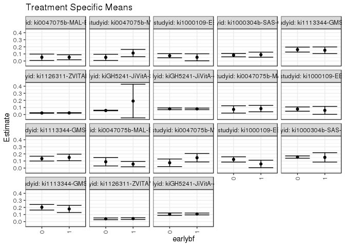

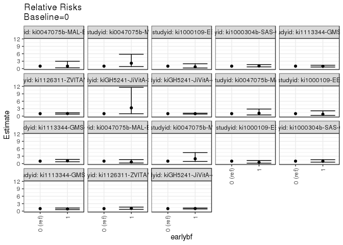

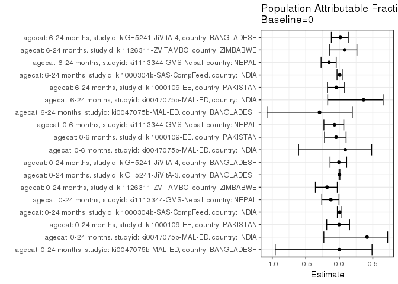

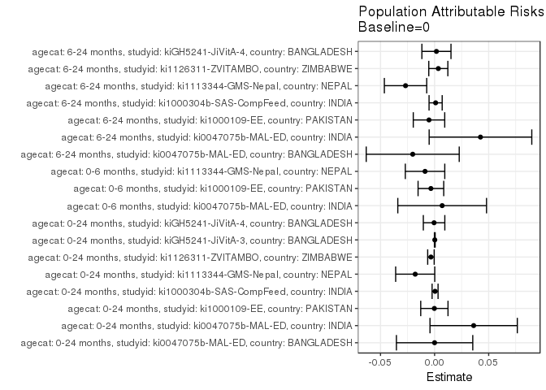

## Results Table

### Parameter: TSM

| agecat | studyid | country | intervention_level | baseline_level | estimate | ci_lower | ci_upper |
| --- | --- | --- | --- | --- | --- | --- | --- |
| 0-24 months | ki0047075b-MAL-ED | BANGLADESH | 0 | NA | 0.0526316 | 0.0076381 | 0.0976251 |
| 0-24 months | ki0047075b-MAL-ED | BANGLADESH | 1 | NA | 0.0526316 | 0.0170611 | 0.0882021 |
| 0-24 months | ki0047075b-MAL-ED | INDIA | 0 | NA | 0.0510204 | 0.0073650 | 0.0946758 |
| 0-24 months | ki0047075b-MAL-ED | INDIA | 1 | NA | 0.1118881 | 0.0601145 | 0.1636618 |
| 0-24 months | ki1000109-EE | PAKISTAN | 0 | NA | 0.0744754 | 0.0449900 | 0.1039607 |
| 0-24 months | ki1000109-EE | PAKISTAN | 1 | NA | 0.0522627 | 0.0023946 | 0.1021307 |
| 0-24 months | ki1000304b-SAS-CompFeed | INDIA | 0 | NA | 0.0830040 | 0.0588611 | 0.1071469 |
| 0-24 months | ki1000304b-SAS-CompFeed | INDIA | 1 | NA | 0.0891089 | 0.0534033 | 0.1248146 |
| 0-24 months | ki1113344-GMS-Nepal | NEPAL | 0 | NA | 0.1610363 | 0.1258985 | 0.1961742 |
| 0-24 months | ki1113344-GMS-Nepal | NEPAL | 1 | NA | 0.1513070 | 0.1047924 | 0.1978216 |
| 0-24 months | ki1126311-ZVITAMBO | ZIMBABWE | 0 | NA | 0.0219871 | 0.0177557 | 0.0262186 |
| 0-24 months | ki1126311-ZVITAMBO | ZIMBABWE | 1 | NA | 0.0227986 | 0.0189396 | 0.0266575 |
| 0-24 months | kiGH5241-JiVitA-3 | BANGLADESH | 0 | NA | 0.0570954 | 0.0530374 | 0.0611534 |
| 0-24 months | kiGH5241-JiVitA-3 | BANGLADESH | 1 | NA | 0.1904762 | -0.0475424 | 0.4284948 |
| 0-24 months | kiGH5241-JiVitA-4 | BANGLADESH | 0 | NA | 0.0810066 | 0.0687093 | 0.0933040 |
| 0-24 months | kiGH5241-JiVitA-4 | BANGLADESH | 1 | NA | 0.0800202 | 0.0693487 | 0.0906918 |
| 0-6 months | ki0047075b-MAL-ED | INDIA | 0 | NA | 0.0721649 | 0.0205628 | 0.1237671 |
| 0-6 months | ki0047075b-MAL-ED | INDIA | 1 | NA | 0.0839161 | 0.0383778 | 0.1294544 |
| 0-6 months | ki1000109-EE | PAKISTAN | 0 | NA | 0.0771812 | 0.0468389 | 0.1075235 |
| 0-6 months | ki1000109-EE | PAKISTAN | 1 | NA | 0.0588235 | 0.0028221 | 0.1148249 |
| 0-6 months | ki1113344-GMS-Nepal | NEPAL | 0 | NA | 0.1335730 | 0.0996454 | 0.1675006 |
| 0-6 months | ki1113344-GMS-Nepal | NEPAL | 1 | NA | 0.1499455 | 0.1034200 | 0.1964710 |
| 6-24 months | ki0047075b-MAL-ED | BANGLADESH | 0 | NA | 0.0888889 | 0.0299679 | 0.1478099 |
| 6-24 months | ki0047075b-MAL-ED | BANGLADESH | 1 | NA | 0.0559441 | 0.0181964 | 0.0936917 |
| 6-24 months | ki0047075b-MAL-ED | INDIA | 0 | NA | 0.0744681 | 0.0212809 | 0.1276553 |
| 6-24 months | ki0047075b-MAL-ED | INDIA | 1 | NA | 0.1459854 | 0.0867315 | 0.2052393 |
| 6-24 months | ki1000109-EE | PAKISTAN | 0 | NA | 0.1220174 | 0.0848410 | 0.1591938 |
| 6-24 months | ki1000109-EE | PAKISTAN | 1 | NA | 0.0580284 | 0.0053630 | 0.1106938 |
| 6-24 months | ki1000304b-SAS-CompFeed | INDIA | 0 | NA | 0.1551918 | 0.1388265 | 0.1715571 |
| 6-24 months | ki1000304b-SAS-CompFeed | INDIA | 1 | NA | 0.1510290 | 0.0845825 | 0.2174756 |
| 6-24 months | ki1113344-GMS-Nepal | NEPAL | 0 | NA | 0.2024321 | 0.1628453 | 0.2420189 |
| 6-24 months | ki1113344-GMS-Nepal | NEPAL | 1 | NA | 0.1786840 | 0.1279296 | 0.2294383 |
| 6-24 months | ki1126311-ZVITAMBO | ZIMBABWE | 0 | NA | 0.0396930 | 0.0275521 | 0.0518340 |
| 6-24 months | ki1126311-ZVITAMBO | ZIMBABWE | 1 | NA | 0.0425103 | 0.0303091 | 0.0547115 |
| 6-24 months | kiGH5241-JiVitA-4 | BANGLADESH | 0 | NA | 0.1051964 | 0.0880819 | 0.1223109 |
| 6-24 months | kiGH5241-JiVitA-4 | BANGLADESH | 1 | NA | 0.1077110 | 0.0947712 | 0.1206509 |

### Parameter: E(Y)

| agecat | studyid | country | intervention_level | baseline_level | estimate | ci_lower | ci_upper |
| --- | --- | --- | --- | --- | --- | --- | --- |
| 0-24 months | ki0047075b-MAL-ED | BANGLADESH | NA | NA | 0.0526316 | 0.0247278 | 0.0805354 |
| 0-24 months | ki0047075b-MAL-ED | INDIA | NA | NA | 0.0871369 | 0.0514552 | 0.1228187 |
| 0-24 months | ki1000109-EE | PAKISTAN | NA | NA | 0.0742706 | 0.0477670 | 0.1007741 |
| 0-24 months | ki1000304b-SAS-CompFeed | INDIA | NA | NA | 0.0834553 | 0.0601989 | 0.1067118 |
| 0-24 months | ki1113344-GMS-Nepal | NEPAL | NA | NA | 0.1431227 | 0.1135034 | 0.1727420 |
| 0-24 months | ki1126311-ZVITAMBO | ZIMBABWE | NA | NA | 0.0186080 | 0.0156964 | 0.0215196 |
| 0-24 months | kiGH5241-JiVitA-3 | BANGLADESH | NA | NA | 0.0572741 | 0.0531873 | 0.0613609 |
| 0-24 months | kiGH5241-JiVitA-4 | BANGLADESH | NA | NA | 0.0805278 | 0.0718757 | 0.0891799 |
| 0-6 months | ki0047075b-MAL-ED | INDIA | NA | NA | 0.0791667 | 0.0449364 | 0.1133970 |
| 0-6 months | ki1000109-EE | PAKISTAN | NA | NA | 0.0737705 | 0.0469540 | 0.1005870 |
| 0-6 months | ki1113344-GMS-Nepal | NEPAL | NA | NA | 0.1247444 | 0.0954276 | 0.1540611 |
| 6-24 months | ki0047075b-MAL-ED | BANGLADESH | NA | NA | 0.0686695 | 0.0361280 | 0.1012111 |
| 6-24 months | ki0047075b-MAL-ED | INDIA | NA | NA | 0.1168831 | 0.0753620 | 0.1584042 |
| 6-24 months | ki1000109-EE | PAKISTAN | NA | NA | 0.1168478 | 0.0839821 | 0.1497135 |
| 6-24 months | ki1000304b-SAS-CompFeed | INDIA | NA | NA | 0.1561462 | 0.1410608 | 0.1712315 |
| 6-24 months | ki1113344-GMS-Nepal | NEPAL | NA | NA | 0.1755725 | 0.1429662 | 0.2081788 |
| 6-24 months | ki1126311-ZVITAMBO | ZIMBABWE | NA | NA | 0.0431393 | 0.0340586 | 0.0522200 |
| 6-24 months | kiGH5241-JiVitA-4 | BANGLADESH | NA | NA | 0.1069074 | 0.0961821 | 0.1176327 |

### Parameter: RR

| agecat | studyid | country | intervention_level | baseline_level | estimate | ci_lower | ci_upper |
| --- | --- | --- | --- | --- | --- | --- | --- |
| 0-24 months | ki0047075b-MAL-ED | BANGLADESH | 0 | 0 | 1.0000000 | 1.0000000 | 1.000000 |
| 0-24 months | ki0047075b-MAL-ED | BANGLADESH | 1 | 0 | 1.0000000 | 0.3362978 | 2.973555 |
| 0-24 months | ki0047075b-MAL-ED | INDIA | 0 | 0 | 1.0000000 | 1.0000000 | 1.000000 |
| 0-24 months | ki0047075b-MAL-ED | INDIA | 1 | 0 | 2.1930070 | 0.8290467 | 5.800976 |
| 0-24 months | ki1000109-EE | PAKISTAN | 0 | 0 | 1.0000000 | 1.0000000 | 1.000000 |
| 0-24 months | ki1000109-EE | PAKISTAN | 1 | 0 | 0.7017444 | 0.2498633 | 1.970858 |
| 0-24 months | ki1000304b-SAS-CompFeed | INDIA | 0 | 0 | 1.0000000 | 1.0000000 | 1.000000 |
| 0-24 months | ki1000304b-SAS-CompFeed | INDIA | 1 | 0 | 1.0735502 | 0.7076965 | 1.628537 |
| 0-24 months | ki1113344-GMS-Nepal | NEPAL | 0 | 0 | 1.0000000 | 1.0000000 | 1.000000 |
| 0-24 months | ki1113344-GMS-Nepal | NEPAL | 1 | 0 | 0.9395829 | 0.6443923 | 1.369998 |
| 0-24 months | ki1126311-ZVITAMBO | ZIMBABWE | 0 | 0 | 1.0000000 | 1.0000000 | 1.000000 |
| 0-24 months | ki1126311-ZVITAMBO | ZIMBABWE | 1 | 0 | 1.0369048 | 0.8037590 | 1.337679 |
| 0-24 months | kiGH5241-JiVitA-3 | BANGLADESH | 0 | 0 | 1.0000000 | 1.0000000 | 1.000000 |
| 0-24 months | kiGH5241-JiVitA-3 | BANGLADESH | 1 | 0 | 3.3361031 | 0.9581662 | 11.615504 |
| 0-24 months | kiGH5241-JiVitA-4 | BANGLADESH | 0 | 0 | 1.0000000 | 1.0000000 | 1.000000 |
| 0-24 months | kiGH5241-JiVitA-4 | BANGLADESH | 1 | 0 | 0.9878233 | 0.8162553 | 1.195453 |
| 0-6 months | ki0047075b-MAL-ED | INDIA | 0 | 0 | 1.0000000 | 1.0000000 | 1.000000 |
| 0-6 months | ki0047075b-MAL-ED | INDIA | 1 | 0 | 1.1628372 | 0.4738821 | 2.853432 |
| 0-6 months | ki1000109-EE | PAKISTAN | 0 | 0 | 1.0000000 | 1.0000000 | 1.000000 |
| 0-6 months | ki1000109-EE | PAKISTAN | 1 | 0 | 0.7621483 | 0.2720922 | 2.134828 |
| 0-6 months | ki1113344-GMS-Nepal | NEPAL | 0 | 0 | 1.0000000 | 1.0000000 | 1.000000 |
| 0-6 months | ki1113344-GMS-Nepal | NEPAL | 1 | 0 | 1.1225736 | 0.7516413 | 1.676560 |
| 6-24 months | ki0047075b-MAL-ED | BANGLADESH | 0 | 0 | 1.0000000 | 1.0000000 | 1.000000 |
| 6-24 months | ki0047075b-MAL-ED | BANGLADESH | 1 | 0 | 0.6293706 | 0.2444123 | 1.620652 |
| 6-24 months | ki0047075b-MAL-ED | INDIA | 0 | 0 | 1.0000000 | 1.0000000 | 1.000000 |
| 6-24 months | ki0047075b-MAL-ED | INDIA | 1 | 0 | 1.9603754 | 0.8621143 | 4.457729 |
| 6-24 months | ki1000109-EE | PAKISTAN | 0 | 0 | 1.0000000 | 1.0000000 | 1.000000 |
| 6-24 months | ki1000109-EE | PAKISTAN | 1 | 0 | 0.4755748 | 0.1825172 | 1.239179 |
| 6-24 months | ki1000304b-SAS-CompFeed | INDIA | 0 | 0 | 1.0000000 | 1.0000000 | 1.000000 |
| 6-24 months | ki1000304b-SAS-CompFeed | INDIA | 1 | 0 | 0.9731766 | 0.5978892 | 1.584027 |
| 6-24 months | ki1113344-GMS-Nepal | NEPAL | 0 | 0 | 1.0000000 | 1.0000000 | 1.000000 |
| 6-24 months | ki1113344-GMS-Nepal | NEPAL | 1 | 0 | 0.8826859 | 0.6259213 | 1.244780 |
| 6-24 months | ki1126311-ZVITAMBO | ZIMBABWE | 0 | 0 | 1.0000000 | 1.0000000 | 1.000000 |
| 6-24 months | ki1126311-ZVITAMBO | ZIMBABWE | 1 | 0 | 1.0709762 | 0.7065569 | 1.623351 |
| 6-24 months | kiGH5241-JiVitA-4 | BANGLADESH | 0 | 0 | 1.0000000 | 1.0000000 | 1.000000 |
| 6-24 months | kiGH5241-JiVitA-4 | BANGLADESH | 1 | 0 | 1.0239043 | 0.8421938 | 1.244820 |

### Parameter: PAR

| agecat | studyid | country | intervention_level | baseline_level | estimate | ci_lower | ci_upper |
| --- | --- | --- | --- | --- | --- | --- | --- |
| 0-24 months | ki0047075b-MAL-ED | BANGLADESH | 0 | NA | 0.0000000 | -0.0352958 | 0.0352958 |
| 0-24 months | ki0047075b-MAL-ED | INDIA | 0 | NA | 0.0361165 | -0.0042449 | 0.0764779 |
| 0-24 months | ki1000109-EE | PAKISTAN | 0 | NA | -0.0002048 | -0.0128128 | 0.0124032 |
| 0-24 months | ki1000304b-SAS-CompFeed | INDIA | 0 | NA | 0.0004514 | -0.0023056 | 0.0032084 |
| 0-24 months | ki1113344-GMS-Nepal | NEPAL | 0 | NA | -0.0179137 | -0.0359833 | 0.0001560 |
| 0-24 months | ki1126311-ZVITAMBO | ZIMBABWE | 0 | NA | -0.0033791 | -0.0063773 | -0.0003810 |
| 0-24 months | kiGH5241-JiVitA-3 | BANGLADESH | 0 | NA | 0.0001786 | -0.0001754 | 0.0005327 |
| 0-24 months | kiGH5241-JiVitA-4 | BANGLADESH | 0 | NA | -0.0004788 | -0.0104140 | 0.0094563 |
| 0-6 months | ki0047075b-MAL-ED | INDIA | 0 | NA | 0.0070017 | -0.0340114 | 0.0480149 |
| 0-6 months | ki1000109-EE | PAKISTAN | 0 | NA | -0.0034107 | -0.0152671 | 0.0084456 |
| 0-6 months | ki1113344-GMS-Nepal | NEPAL | 0 | NA | -0.0088286 | -0.0270704 | 0.0094132 |
| 6-24 months | ki0047075b-MAL-ED | BANGLADESH | 0 | NA | -0.0202194 | -0.0632153 | 0.0227765 |
| 6-24 months | ki0047075b-MAL-ED | INDIA | 0 | NA | 0.0424150 | -0.0050254 | 0.0898554 |
| 6-24 months | ki1000109-EE | PAKISTAN | 0 | NA | -0.0051695 | -0.0197083 | 0.0093692 |
| 6-24 months | ki1000304b-SAS-CompFeed | INDIA | 0 | NA | 0.0009544 | -0.0051121 | 0.0070209 |
| 6-24 months | ki1113344-GMS-Nepal | NEPAL | 0 | NA | -0.0268596 | -0.0464401 | -0.0072790 |
| 6-24 months | ki1126311-ZVITAMBO | ZIMBABWE | 0 | NA | 0.0034463 | -0.0053715 | 0.0122641 |
| 6-24 months | kiGH5241-JiVitA-4 | BANGLADESH | 0 | NA | 0.0017110 | -0.0117344 | 0.0151564 |

### Parameter: PAF

| agecat | studyid | country | intervention_level | baseline_level | estimate | ci_lower | ci_upper |
| --- | --- | --- | --- | --- | --- | --- | --- |
| 0-24 months | ki0047075b-MAL-ED | BANGLADESH | 0 | NA | 0.0000000 | -0.9554502 | 0.4886088 |
| 0-24 months | ki0047075b-MAL-ED | INDIA | 0 | NA | 0.4144801 | -0.2301792 | 0.7213141 |
| 0-24 months | ki1000109-EE | PAKISTAN | 0 | NA | -0.0027579 | -0.1877207 | 0.1534008 |
| 0-24 months | ki1000304b-SAS-CompFeed | INDIA | 0 | NA | 0.0054088 | -0.0286322 | 0.0383232 |
| 0-24 months | ki1113344-GMS-Nepal | NEPAL | 0 | NA | -0.1251629 | -0.2608949 | -0.0040422 |
| 0-24 months | ki1126311-ZVITAMBO | ZIMBABWE | 0 | NA | -0.1815949 | -0.3562605 | -0.0294236 |
| 0-24 months | kiGH5241-JiVitA-3 | BANGLADESH | 0 | NA | 0.0031191 | -0.0030580 | 0.0092583 |
| 0-24 months | kiGH5241-JiVitA-4 | BANGLADESH | 0 | NA | -0.0059464 | -0.1373018 | 0.1102378 |
| 0-6 months | ki0047075b-MAL-ED | INDIA | 0 | NA | 0.0884428 | -0.6070774 | 0.4829517 |
| 0-6 months | ki1000109-EE | PAKISTAN | 0 | NA | -0.0462342 | -0.2190996 | 0.1021194 |
| 0-6 months | ki1113344-GMS-Nepal | NEPAL | 0 | NA | -0.0707737 | -0.2292727 | 0.0672889 |
| 6-24 months | ki0047075b-MAL-ED | BANGLADESH | 0 | NA | -0.2944444 | -1.0791678 | 0.1941072 |
| 6-24 months | ki0047075b-MAL-ED | INDIA | 0 | NA | 0.3628842 | -0.1722863 | 0.6537394 |
| 6-24 months | ki1000109-EE | PAKISTAN | 0 | NA | -0.0442416 | -0.1757536 | 0.0725604 |
| 6-24 months | ki1000304b-SAS-CompFeed | INDIA | 0 | NA | 0.0061121 | -0.0335248 | 0.0442288 |
| 6-24 months | ki1113344-GMS-Nepal | NEPAL | 0 | NA | -0.1529828 | -0.2711067 | -0.0458361 |
| 6-24 months | ki1126311-ZVITAMBO | ZIMBABWE | 0 | NA | 0.0798869 | -0.1481824 | 0.2626536 |
| 6-24 months | kiGH5241-JiVitA-4 | BANGLADESH | 0 | NA | 0.0160046 | -0.1181467 | 0.1340608 |